# Diversity of opsins in transcriptomes of Baikal endemic amphipods

#### **Checking if quality of transcriptome assembly depends on taxonomic position of amphipod**

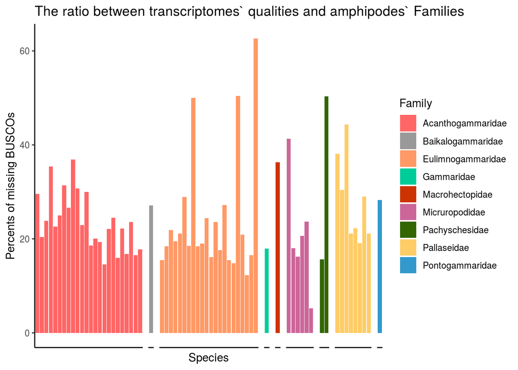

```r
ggplot(df, aes(fill = Family, x = Species, y = Missing_BUSCOs)) +
  geom_bar(stat = 'identity', position = 'dodge') +
  theme_classic() +
  theme(axis.text.x=element_blank(),
       axis.ticks.x=element_blank()) +
  facet_grid(. ~ Family, space = 'free_x', scales = 'free_x') +
 theme(
    strip.background = element_blank(),
    strip.text.x = element_blank()
  ) +
 scale_fill_manual(values = c("#FF6666", "#999999", "#FF9966", "#00CC99", "#CC3300", "#CC6699", "#336600", "#FFCC66", "#3399CC")) +
 labs( title = 'The ratio between transcriptomes` qualities and amphipodes` Families',
        y = 'Percents of missing BUSCOs',
        x = 'Species')
```

Taxonomic position does not influence the quality of transcriptome assembly in this case.

#### **Checking if the amount of identified opsins` genes depends on quality of transcriptome assembly**

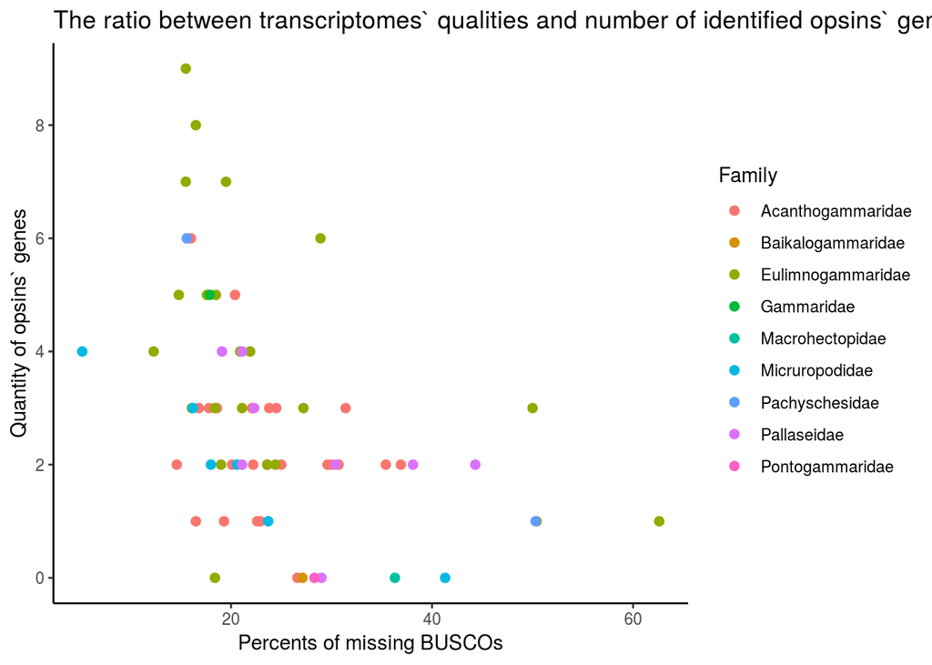

```r
ggplot(df, aes(Missing_BUSCOs, eValue_e.10, colour = Family)) +
  geom_point(size = 2) +
  scale_y_continuous(breaks= pretty_breaks()) +
  labs( title = 'The ratio between transcriptomes` qualities and number of identified opsins` genes (E-value = e-10)',
        y = 'Quantity of opsins` genes',
        x = 'Percents of missing BUSCOs') +
  theme_classic()
```

Quality of transcriptome assembly influences final amount of identified opsins` genes. The less percentage of Missing BUSCOs is, the more opsins have been found in transcriptome.